# Visualization

Previous: Analysis. Next: References. Up: Index.

During the embedding, `sneer` will display the current state of the output configuration. But you can also use a standalone function to visualize the coordinates (or any 2D matrix), so we’ll look at that first while we run through the different options available.

## `embed_plot`

`embed_plot` is a function you can use to easily view the results of the plot. Just looking at the output as an undifferentiated mass is rarely enlightening, so you will normally want to color the points in some way. Three main strategies come to mind:

- If you have already got a column in the data frame that contains colors, use that.
- Where the data falls into a set of categories, map from those categories to a color.
- If you have a number associated with each point (e.g. from one of vectors you can export from the embedding), you might want to map those numbers to a color scale and project the values onto the points.

`embed_plot` can help you with that. However, if you go with the categories-to-colors plot, you won’t get a legend, so you will be able to discern any clustering by the colors, but you won’t know which color maps to which category. Sorry. I was unable to find a satisfactory solution with the standard `graphics::plot` commands that could guarantee the legend would be in a sensible place and location for arbitrary numbers of categories and category names of arbitrary length.

Anyway, let’s run through some examples. Let’s do a quick tsne embedding on our old friend the iris dataset, and lets extract the degree centrality (`deg`) and embedding error (`pcost`) of each node too so we have something numeric to project onto the plot.

```r
tsne_iris <- sneer(iris, max_iter = 200, ret = c("deg", "pcost"))
```

### Default

Let’s take a look at the embedding:

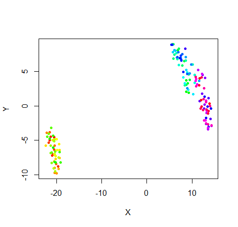

`embed_plot(tsne_iris$coords)`

Well, that’s garish. This is because you haven’t provided any color information, so the default is that each point gets its own color from the default color scheme, which happens to be the `grDevices::rainbow` function. This might be useful for some simulation data sets where the data is produced by a sequential function of some kind (e.g. a random walk or a path around a circle or some other parametric function) and the progression of the color gives some clue about location.

You can also omit the “$coords” bit when passing the result of `sneer` to `embed_plot`:

```r
embed_plot(tsne_iris$coords)

# Same as the above, less typing
embed_plot(tsne_iris)
```

### Explicit `colors`

If you just want everything to be one color, pass that to the `colors` parameter:

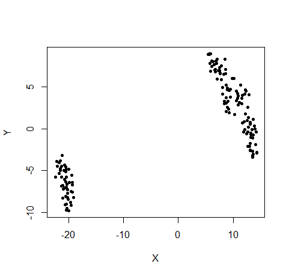

`embed_plot(tsne_iris$coords, colors = "black")`

If you have a preset vector of colors, that makes a lot more sense. Perhaps, inspired by the technicolor dream plot of the first example, you want each iris to have its own random color:

```r
niris <- nrow(iris)
iris_colors <- rgb(runif(niris), runif(niris), runif(niris))
```

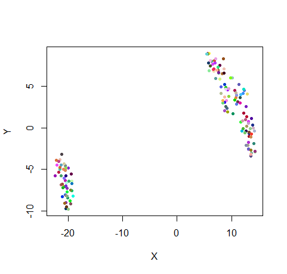

`embed_plot(tsne_iris$coords, colors = iris_colors)`

Beautiful.

More sensibly, the datasets used in [How to use t-SNE Effectively](http://distill.pub/2016/misread-tsne/), and available in the github package snedata have a pre-calculated `color` column.

Do the installation, and then carry out PCA on the three clusters simulation data:

```r
devtools::install_github("jlmelville/snedata")
library("snedata")
three_c <- three_clusters_data(50)
pca_3c <- sneer(three_c, method = "pca")
```

View the results with a less foolish set of colors than random:

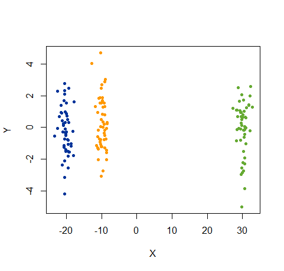

`embed_plot(pca_3d$coords, colors = three_c$color)`

### Mapping from factor levels to colors

Back to our long-suffering iris example. It consists of measurements of the sepal and petal dimensions of 150 flowers, from 3 species: *Iris setosa*, *Iris versicolor* and *Iris virginica*. That species information is in the `iris$Species` column, so it would be natural to map from those categories to colors.

To do this, pass the `iris$Species` column to the `x` argument. This argument can be a data frame or a column. `embed_plot` will try and work out what to do based on what it’s passed. In this case, the result is:

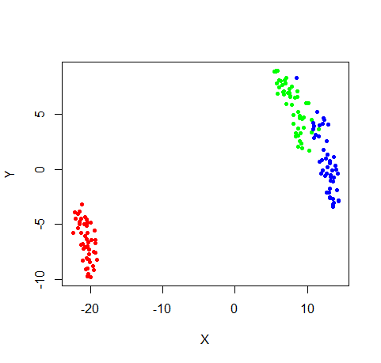

`embed_plot(tsne_iris$coords, x = iris$Species)`

Three species, three colors (sorry you can’t see a legend).

### `color_scheme`

If you don’t like the color scheme used, you can change it by passing a different color function to `color_scheme`. For example, here’s the use of the `topo.colors` function, also from the `grDevices` package, like `rainbow`:

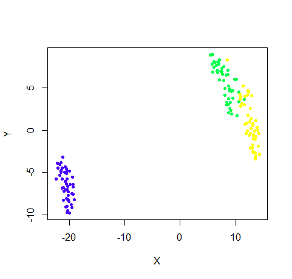

`embed_plot(tsne_iris$coords, x = iris$Species, color_scheme = topo.colors`)

You can write your own color function as long as it follows the same interface as the ones in `grDevices`: you pass in a single integer, `n`, and you get back a vector of `n` colors. For instance, perhaps you really liked those random colors. Enshrine your non-deterministic creativity as a function:

```r
random_colors <- function(n) {
  rgb(runif(n), runif(n), runif(n)
}
```

Now, whenever you want each iris species to get a random color, it’s as simple as:

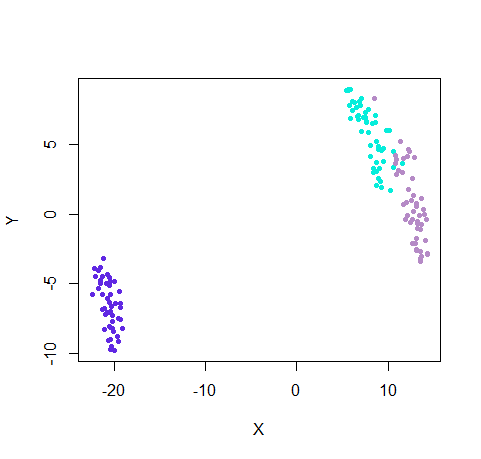

`embed_plot(tsne_iris$coords, x = iris$Species, color_scheme = random_colors`)

### `RColorBrewer`

If, like me, you have little creativity when it comes to picking color schemes, I recommend just deferring to the [ColorBrewer](http://colorbrewer2.org/) color schemes (although [other color schemes exist](https://tradeblotter.wordpress.com/2013/02/28/the-paul-tol-21-color-salute/)). These are available both for numerical scales, and for mapping categorically. Use the RColorBrewer package to get access to them in R. You need to install and load it manually if you want to use it with `embed_plot`:

```r
install.packages("RColorBrewer")
library(RColorBrewer)
```

To use a scheme from ColorBrewer, pass the *name* of a scheme to the `color_scheme` parameter, rather than a function. Find the names by running `RColorBrewer::brewer.pal.info()` or `RColorBrewer::display.brewer.all()`.

For mapping factors to colors, you should be using one of the “qual” (short for “qualitative”) schemes, for example “Accent”:

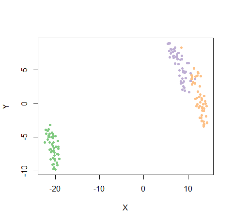

`embed_plot(tsne_iris$coords, x = iris$Species, color_scheme = "Accent")`

If the data set you are using has more factors than the color scheme has colors, `embed_plot` attempts to interpolate the colors into a new set of colors. Not ideal, but better than nothing.

### Passing a data frame to `x`

Previously, I mentioned that if you pass a data frame rather than a vector to the `x` parameter, the function will attempt to do the right thing. What this means in practice is:

- first of all, it looks for a column of strings, where each member can be interpreted as a color. If it finds one, it will use that for colors. If it finds more than one, it uses the last column it finds.
- otherwise, if looks for a factor column. If it finds one, it maps that to colors as if you had passed the column directly. Again, if more than one column is found, it uses the last one it finds.
- otherwise, as you have seen, you get one color per point.

This is a convenience for when you have multiple data sets you’re looking at, they have different column names and types that you want to use for coloring and you don’t want to remember them all.

As `x` is the second argument to `embed_plot` positionally, you don’t even need to refer to it by name, which makes using `embed_plot` even easier. For example, the following pairs of invocations are equivalent to each other:

```r
embed_plot(pca_3d$coords, colors = three_c$color)
embed_plot(pca_3d$coords, three_c) # will find the "color" column

embed_plot(tsne_iris$coords, x = iris$Species)
embed_plot(tsne_iris$coords, iris) # will find the "Species" column

embed_plot(tsne_iris$coords, colors = iris_colors)
# detects it's already been passed a color vector when passed as 'x' argument
embed_plot(tsne_iris$coords, iris_colors)
```

### Factor levels as text

In some cases, you may want to plot the factor levels you’re using for the color scheme as labels on the plot, instead of the points themselves, especially because of the lack of a legend. To do this, set the `text` argument to the column you want to use. Let’s finally find out which species is which in the iris plot:

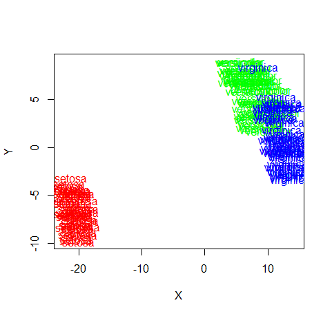

`embed_plot(tsne_iris$coords, iris, text = iris$Species)`

Um, I suppose you can just about make out the names. Perhaps it’ll look better if we reduce the size of the text with the `cex` parameter and only plot the first two characters of the species name?

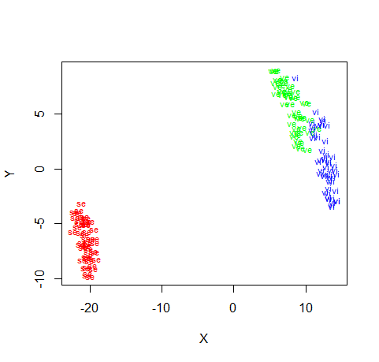

`embed_plot(tsne_iris$coords, iris, text = substr(iris$Species, 1, 2), cex = 0.7)`

That’s a bit better. As you can see, this probably isn’t a great option, unless you have a small dataset with short labels.

### Mapping numeric vectors

You can also map a numeric vector to a point. For example, if you use return the point-wise decomposition of the cost function, `pcost`, you can get a sense for which points have been well-embedded. It’s important to avoid drawing conclusions about similarity of points based on their embedded proximity if they have a high individual embedding error.

Choosing a good color scheme is very important here, so I recommend the ColorBrewer sequential and diverging schemes. Here’s the iris t-SNE absolute error plot with the “Blues” sequential color scheme:

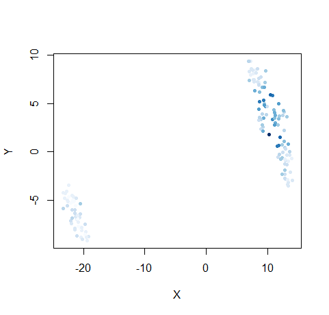

`embed_plot(tsne_iris$coords, abs(tsne_iris$pcost), color_scheme = "Blues")`

I’ve use `abs(tsne_iris$pcost)`, because for the Kullback-Leibler divergence, the individual point-wise error can be negative or positive. For this example, though, I only care about the magnitude of the embedding error. The *setosa* class down in the bottom left is very well embedded, the light blue color indicating little contribution to the embedding error. The embedding clearly had a bit more trouble where the *virginica* and *versicolor* clusters overlap.

The degree centrality - a measure of how “important” each point is - might also provide some information, although note that it is calculated using the input probability only. It’s not using the output coordinates or error directly. Once again, we’ll use the Blues color scheme:

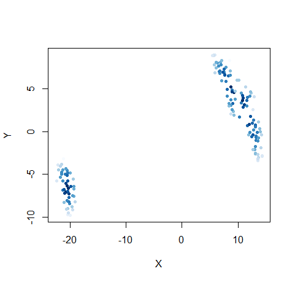

`embed_plot(tsne_iris$coords, tsne_iris$deg, color_scheme = "Blues")`

As you can see, sequential schemes highlight large values. If you want to highlight values at both ends of the scale, use a diverging scale, like `RdYlGn`:

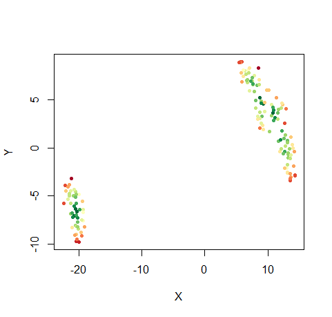

`embed_plot(tsne_iris$coords, tsne_iris$deg, color_scheme = "RdYlGn")`

### Extra parameters for numerical mapping

There are some extra parameters that can be used to control the display of the numerical mapping. Sometimes, you may only want to see the points with the largest values. Use the `top` argument for this. For example, here are the top 15 most important iris points:

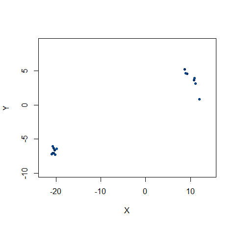

`embed_plot(tsne_iris$coords, tsne_iris$deg, color_scheme = "Blues", top = 15)`

By default the color scheme is mapped to the extent of the numerical vector you provide. Sometimes, there’s an absolute scale you may want to use, however. For instance, the neighborhood preservation value, discussed in greater detail in the Analysis section takes a value between 0 and 1, representing an embedded point that has retained none or all of its neighbors, respectively.

Let’s see how well PCA does at preserving each point’s 25 neighbors. Note that we need to `ret`urn the input distance matrix (`dx`) and output distance matrix (`dy`) for the `nbr_pres` calcuation:

```r
pca_iris <- sneer(iris, ret = c("dx", "dy"), method = "pca")
pca_nbrp25 <- nbr_pres(pca_iris$dx, pca_iris$dy, 25)
```

Running `summary(pca_nbrp25)` shows that PCA does a pretty good job:

```
   Min. 1st Qu.  Median    Mean 3rd Qu.    Max.
 0.5600  0.8800  0.9200  0.8939  0.9600  1.0000
```

If we plot the nbr preservation values as colors (with the size of the points increased via the `cex` parameter):

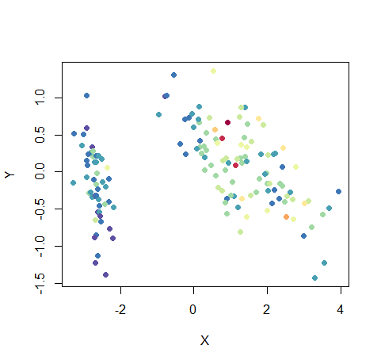

`embed_plot(pca_iris$coords, pca_nbrp25, color_scheme = "Spectral", cex = 1.5)`

There are a few red points in the middle of the two right hand clusters - that’s where the points have the lowest neighborhood preservations are. But given they’re never lower than 0.56, you could replot this, using the full preservation scale, by passing the lower and upper limits to the `limits` argument:

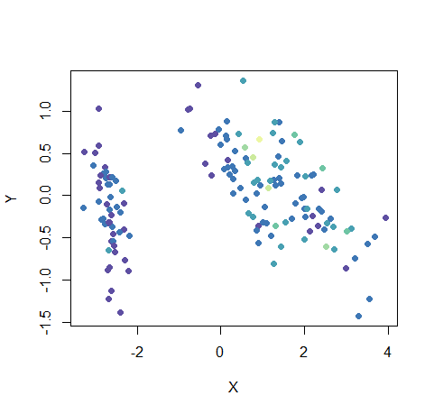

`embed_plot(pca_iris$coords, pca_nbrp25, color_scheme = "Spectral", cex = 1.5, limits = c(0, 1))`

Doesn’t seem so bad now those red points have turned yellow.

### Miscellaneous

There are a few other commands that can modify the look of the plot.

As we’ve seen in a few places, `cex` scales the size of the points (or the text if the `text` argument is used). Set it to less than 1 to make the points smaller than default, and greater than 1 to make them bigger.

`equal_axes`, if set to `TRUE` will make the extent of the X and Y axis the same. This is useful if you would rather have a 1:1 aspect ratio, at the expense of more whitespace and in your plot. Here’s the iris plot yet again, now with equal X and Y axes:

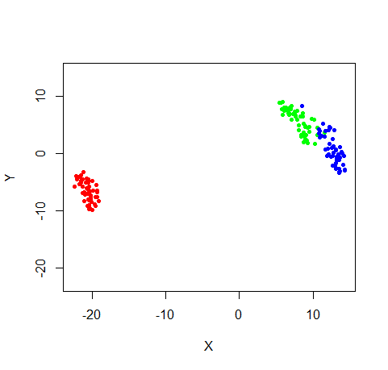

`embed_plot(tsne_iris$coords, iris, equal_axes = TRUE)`

The clusters now look a lot less “tall” and stretched in the vertical direction.

## Plotting in `sneer`

Much of what has been described here applies to the plots which appear during the embedding process when running `sneer`. Here are the options to be aware of.

### `colors`, `color_name`

You may provide a vector of colors directly to `sneer` via the `colors` parameter, or the name of a column in the data frame via `color_name`.

```r
sneer(three_c, colors = three_c$color)
sneer(three_c, color_name = "color") # the same as the previous command
```

### `labels`, `label_name`

Similarly, you can map from a factor to colors with the `labels` and `label_name` parameters:

```r
sneer(iris, labels = iris$Species)
sneer(iris, label_name = "Species") # the same as the previous command
```

### Defaults

Just like `embed_plot`, `sneer` will try and find a color of label column from the data frame you pass it:

```r
sneer(iris, labels = iris$Species)
sneer(iris) # equivalent to the above
```

The same rules for finding columns applies for `sneer` as for `embed_plot`: color columns are returned in preference to factor columns, and if nothing is found, one color is used per point. If more than one column is found, the last column is used.

### `color_scheme`

You can specify the color scheme just like in `embed_plot`: pass either a color function like `rainbow` or the *name* of a ColorBrewer color scheme, e.g. `"Set1"`.

### `plot_type`

If you embed in other than 2 dimensions, you won’t see a plot. You can also turn off plotting by setting `plot_type = "none"`.

There is also support for using `ggplot2`. As usual, you need to install and load it yourself:

```r
install.package("ggplot2")
library(ggplot2)
```

Then, set `plot_type = "ggplot2"` (or just `"g"`):

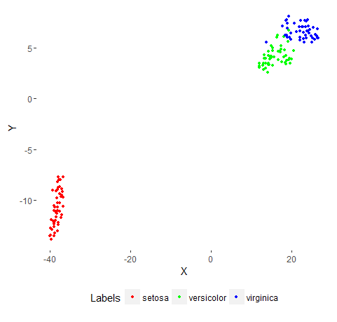

`tsne_iris <- sneer(iris, plot_type = "ggplot2")`

Could that be..? Yes it is. It’s a legend at long, long last. This is the big advantage of using the `ggplot2` plotting during the embedding. It’s not currently supported by `embed_plot`.

Before you get too excited about legends and everything there are some downsides to using it. First, even though positioning the legend works much better with `ggplot2` than using `plot`, you still can have a horrible things happen if you have a very large legend (because of lots of categories or long category names). You can try fiddling with the `legend_rows` parameter in this case, which specifies how many rows to try and lay the legend out on. This might help prevent the legend from getting too high or wide. If the worst comes to the worst you can set the `legend` parameter to `FALSE` to turn it off.

Also, coloring the plot has to be done by mapping from a factor to a color scheme currently (i.e. no columns of explicit color names). Finally, you can’t choose to display factor labels instead of points (but at least you have a legend).

### `cex`

As with `embed_plot`, the `cex` parameter changes the size of the plotted points.

### `equal_axes`

Set this to `TRUE` to have the axes have the same scale.

### `plot_labels`

If `TRUE`, whatever factor column provided to `sneer` (or it finds itself) will be plotted as labels on the embedding plot. As discussed under the `text` parameter of `embed_plot`, has limited (but not zero) use.

## `embed_plotly`

As an alternative to `embed_plot`, you can try out `embed_plotly`, which uses the JavaScript charting library [plotly](https://plot.ly) and its R API to generate embedding plots. You will need to install the plotly package, ensuring the version you are using is at least version 4:

```r
install.package("plotly")
library("plotly")
packageVersion("plotly") # This needs to begin with '4.'
```

If you’re using [RStudio](https://www.rstudio.com/), calling `embed_plotly` won’t seem all that different to using `embed_plot`. However, if you’re using the usual R shell, then it will open the plot in your default web browser. If you can handle that, then there are a few advantages to using plotly. First:

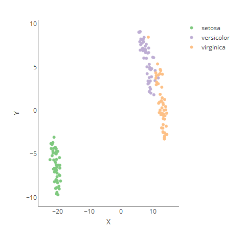

`embed_plotly(tsne_iris$coords, iris$Species, color_scheme = "Accent")`

Yep, you get a legend.

Second:

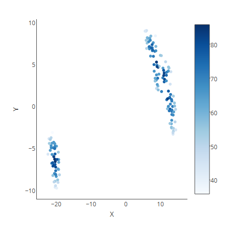

`embed_plotly(tsne_iris$coords, tsne_iris$deg, color_scheme = "Blues")`

And numeric vectors gets a color scale. Also, if you pass in some labels as the `text` argument, they will show up in a tooltip if you hover over a point.

Third, there are lots of panning and zooming options if you want to interactively explore different areas of the plot in more detail.

The only minor downside to the use of `embed_plotly` is that it doesn’t support the `limits` and `top` arguments when used with a numeric vector. A small price to pay.

Previous: Analysis. Next: References. Up: Index.